# Системы контроля версий

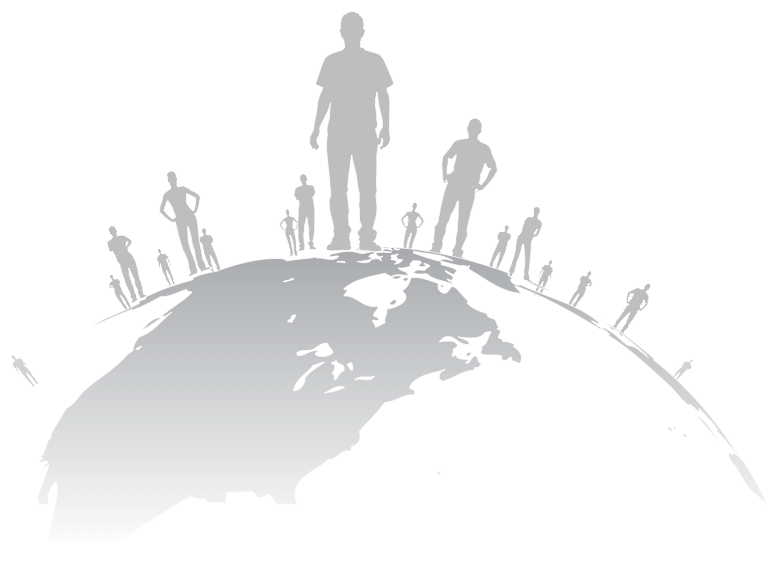

Кирилл Корняков (Itseez, ННГУ)  
1 Октября 2013

# Содержание

1. Введение
2. Git
3. Командная работа

# Введение

Перед каждым проектом, в особенности коллективным, встают следующие задачи:

1. Небходимо **центральное** хранилище кода
   - Официальное, актуальное, защищенное, используемое всеми участниками
2. Нужно уметь возвращаться к **прошлым** версиям
   - Откат дефектных изменений, поиск ошибок сравнением, извлечение кода "из прошлого"

Нужны ли специальные инструменты?

# Три поколения VCS

Локальные

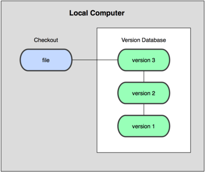

# Три поколения VCS

Централизованные

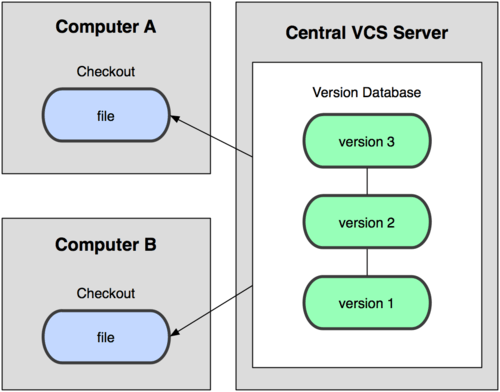

# Три поколения VCS

Распределенные

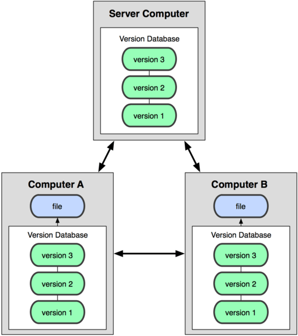

# Три поколения VCS

| Generation | Networking | Operations | Concurrency | Examples |
| --- | --- | --- | --- | --- |
| First | None | One file at a time | Locks | RCS, SCCS |
| Second | Centralized | Multi-file | Merge before commit | CVS, SourceSafe, Subversion, Team Foundation Server |
| Third | Distributed | Changesets | Commit before merge | Bazaar, Git, Mercurial |

Eric Sink ["A History of Version Control"](http://www.ericsink.com/vcbe/html/history_of_version_control.html)

# Общие сведения

> **Системы контроля версий** - это программные системы, хранящие несколько версий одного документа, и позволяющие вернуться к более ранним версиям. Как правило, для каждого изменения запоминается дата модификации и автор.
- Как правило используются для хранения исходного кода (source control), но имеются и другие применения: конфигурации, документация, компьютерная анимация, САПР и др.
- На сегодняшний момент являются одним из ключевых инструментов разработки, появляется все больше примеров использования в других отраслях ([книгоиздание](https://github.com/certik/theoretical-physics), [государственные документы](http://www.youtube.com/watch?v=CEN4XNth61o)).

# Основные термины

- repository
- working copy
- revision
- head
- check-out, clone
- update, sync
- check-in, commit, submit
- commit, changeset, patch
- pull/merge request
- merge, integration
- conflict
- rebase
- shelving, stashing
- branch
- trunk, mainline, master
- tag, label

Глоссарий

# Патчи

**Патч** (англ. patch — заплатка) — информация, предназначенная для автоматизированного внесения определённых изменений в компьютерные файлы.

**Unified diff format**:

> `@@ -l,s +l,s @@ optional section heading`

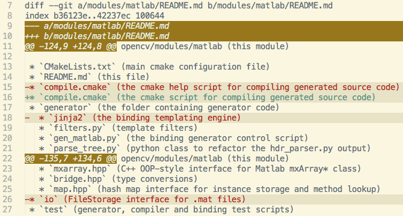

# Типичные функции

1. Централизованное хранение исходного кода
   - Актуальное "официальное" состояние проекта
   - Удаленный доступ к проекту
   - Разграничение прав доступа
   - Использование в качестве запасного (backup) хранилища экспериментальных веток
2. Возможность получения более ранних версий файлов
   - Получение истории индивидуального файла
   - Получение среза (snapshot) всего проекта

# Базовые принципы

1. Приложение строится только на на основе известного состояния репозитория:
   - Не только релизы, но и экспериментальные и тестовые сборки (builds).
   - В идеале приложение умеет сообщать свою ревизию и параметры сборки.
2. Стабильность общих (публичных) веток:
   - Они обязаны компилироваться и проходить все тесты в любой момент времени.
   - Изменения тестируются до попадания в репозиторий.
   - Если дефектные изменения прошли, они исправляются в срочном порядке.
3. Абсолютно вся разработка фиксируется в истории:
   - Это делается в виде отдельных веток локального или глобального репозитория.
   - "Удачные" изменения добавляются в основную ветвь.
4. Публичная история проекта не "переписывается":
   - Однажды помеченные тэгами и выпущенные релизы модификации не подлежат.
   - Промежуточная история не переписывается, потому что будут конфликты.

# Текущий статус

[figure not shown]

[DevProd Report Revisited: Version Control Systems in 2013](http://zeroturnaround.com/rebellabs/devprod-report-revisited-version-control-systems-in-2013/#!/)

# Git

[figure not shown]

- Изначально разработан Линусом Торвальдсом для работы над ядром Linux.
- В настоящее время поддерживается Джунио Хамано, сотрудником Google.
- Не очень прост в освоении, однако очень быстрый и функциональный.
- Имеет наиболее "сильное" сообщество, инструментальную поддержку.
- Официальный сайт проекта: http://www.git-scm.org.

# Три состояния файлов

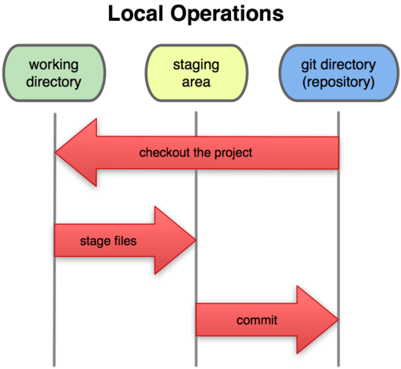

# Git Objects

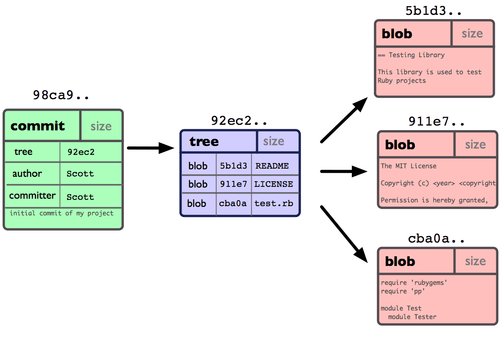

# Git Commits

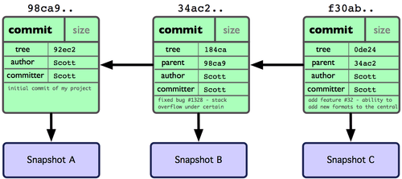

# Master

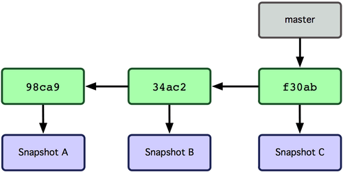

# Git `branch`

```
$ git branch testing
```

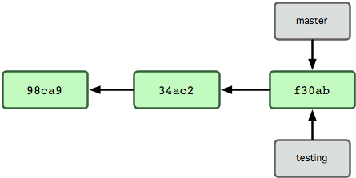

# HEAD

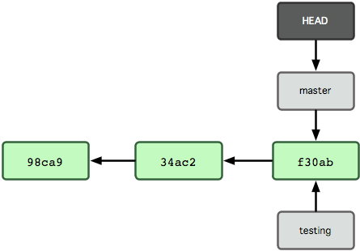

# Git `checkout`

```
$ git checkout testing
```

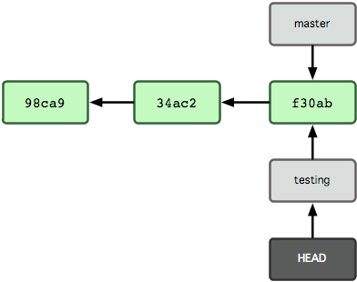

# Git `commit`

```
$ vim README.md
$ git commit -a -m 'made a change'
```

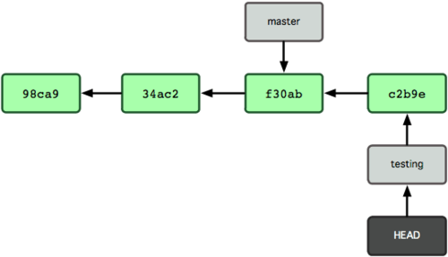

# Go back to `master`

```
$ git checkout master
```

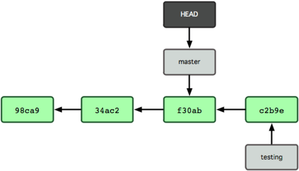

# Make a commit to `master`

```
$ vim main.cpp
$ git commit -a -m 'made other changes'
```

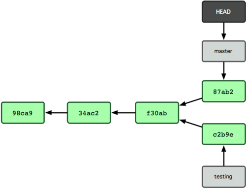

# Merging

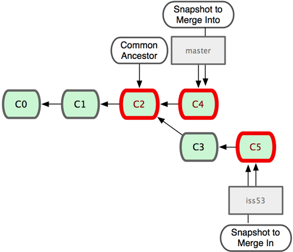

# Merging

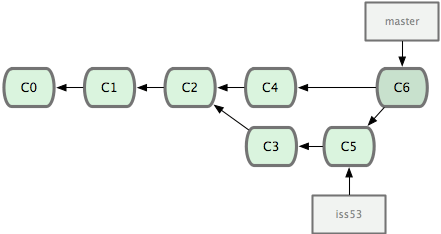

# Multiple branches

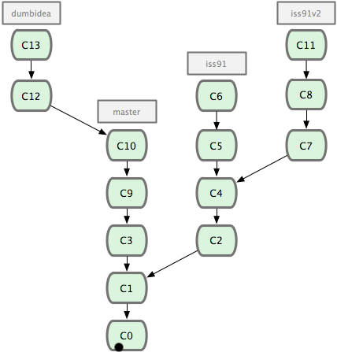

# Нестандартные применения Git

1. Хранилище для веб-контента ([GitHub pages](http://pages.github.com), draft devtools [page](http://unn-vmk-software.github.io/devtools-course/)).
2. Легковесная база данных.

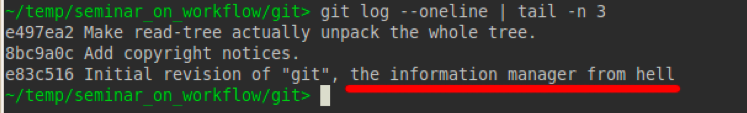

3. Git можно использовать программно при помощи libgit2,  
   практически из любого популярного языка.

# Рабочие процессы

1. Распределенные рабочие процессы (workflow)
   - Centralized
   - Integration Manager
   - Dictator and Lieutenants
2. Модели ветвления (branching model)
   - GitHub Flow
   - GitFlow

# Centralized Workflow

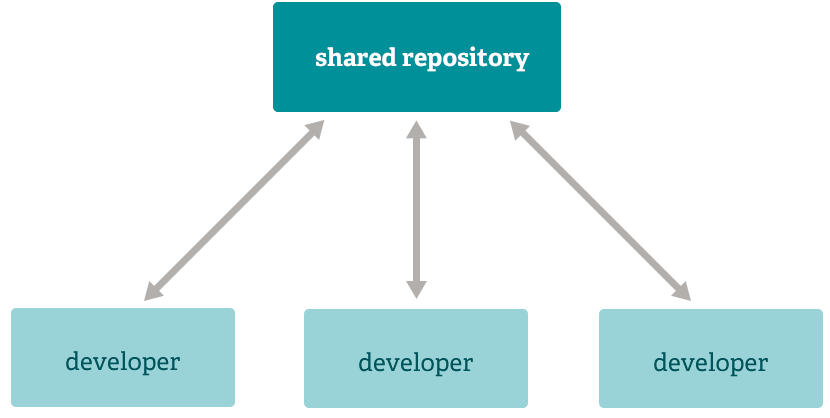

# Integration Manager Workflow

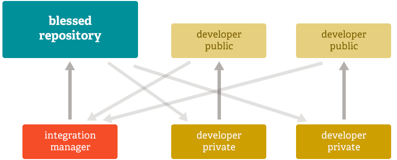

# Dictator and Lieutenants Workflow

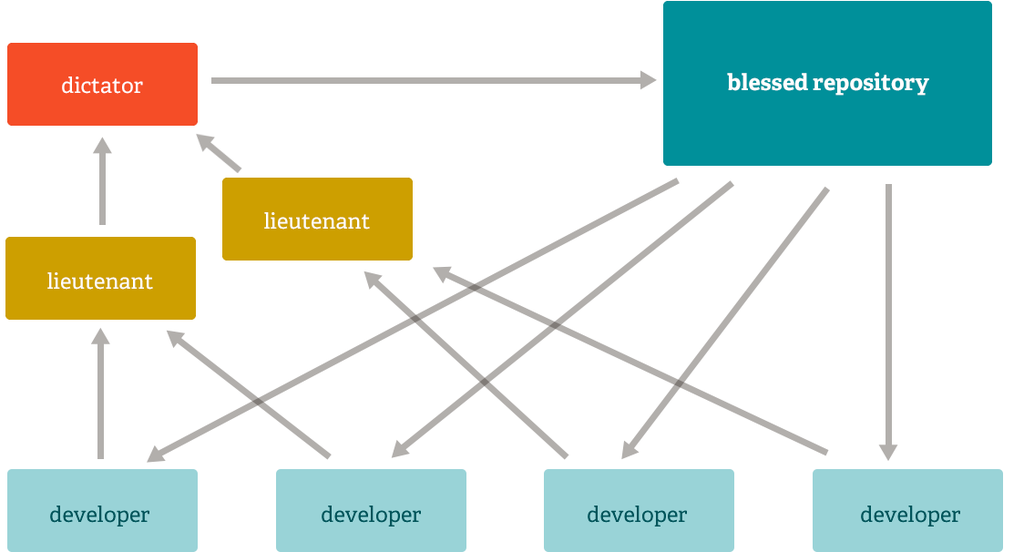

# GitHub Flow

[figure not shown]

[GitHub Flow](http://scottchacon.com/2011/08/31/github-flow.html)

# GitHub Flow

- Anything in the `master` branch is deployable.
1. Create branch
   - To work on something new, create a descriptively named branch off of `master` (ie: `new-oauth2-scopes`).
2. Develop in branch
   - Commit to that branch locally and regularly push your work to the same named branch on the server.
3. Open a pull request (ask for review)
   - When you need feedback or help, or you think the branch is ready for merging, open a pull request.
4. Merge after review
   - After someone else has reviewed and signed off on the feature, you can merge it into `master`.
5. Deploy
   - Once it is merged and pushed to `master`, you can and *should* deploy immediately.

# Git Flow

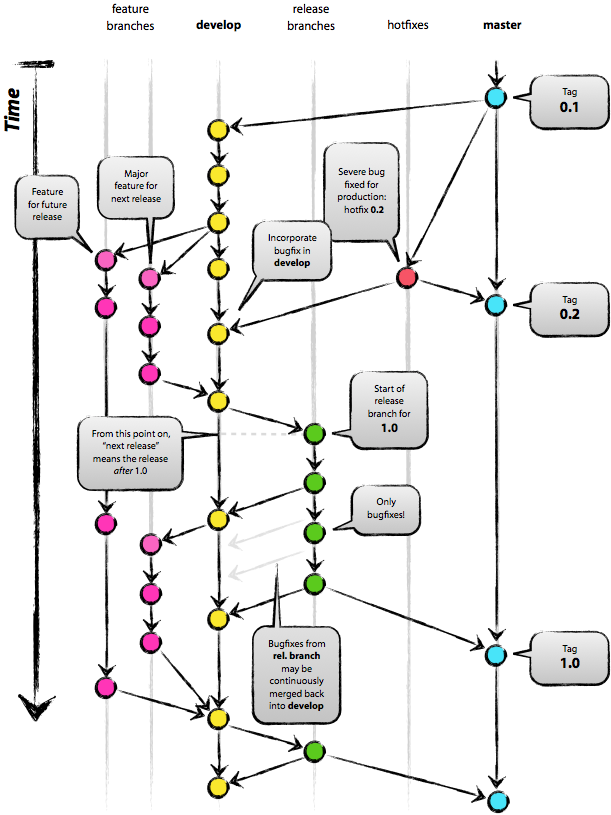

A successful Git branching model ([link](http://nvie.com/posts/a-successful-git-branching-model/))

# Резюме

1. Системы контроля версий - незаменимый инструмент разработки
   - Централизованный доступ (при полностью распределенной разработке)
   - Навигация по истории изменений
2. Необходимо следовать общепринятым правилам и практикам,  
   в особенности относительно публичных репозиториев и релизов.
3. Git не самая простая в освоении СКВ, однако очень функциональная,  
   к тому же дает максимальную свободу по организации процесса разработки.
4. Каждому проекту следует выработать свой рабочий процесс и правила именования веток.  
   При этом желательно пользоваться популярными подходами.

# Контрольные вопросы

1. Определение СКВ.
2. Основные функции/возможности современных СКВ.
3. Базовые принципы корректной работы с СКВ.
4. Рабочий процесс (модель ветвления), используемый в компании GitHub.

# Ссылки

1. Wikipedia "Системы контроля версий".
2. [Pro Git](http://git-scm.com) by Scott Chacon.
3. ["Mercurial tutorial"](http://hginit.com) by Joel Spolsky.

# Спасибо!

Вопросы?